# presentation slides

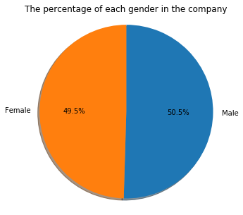

```python
plt.figure(figsize=(5,5))
plt.title('The percentage of each gender in the company')
pie('gender')
plt.show()
```

**The company has an approximately equal number of genders**

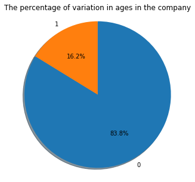

```python
plt.figure(figsize=(5,5))
plt.title('The percentage of variation in ages in the company')
pie('SeniorCitizen')
plt.show()
```

**16.2% of the company's clients are elderly and the rest are young**

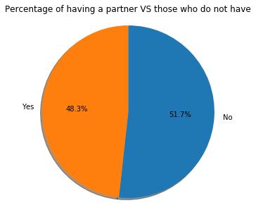

```python
plt.figure(figsize=(5,5))
plt.title('Percentage of having a partner VS those who do not have')
pie('Partner')
plt.show()
```

**51% of clients don't have a partner**

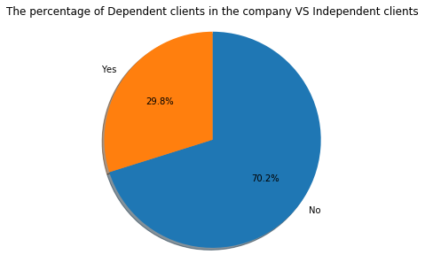

```python
plt.figure(figsize=(5,5))
plt.title('The percentage of Dependent clients in the company VS Independent clients')
pie('Dependents')
plt.show()
```

**we can see 70.2% of clints are Independent**

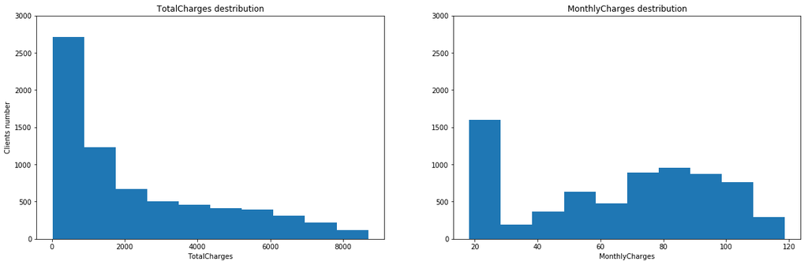

```python
plt.figure(figsize=(20,6))
plt.subplot(1,2,1)
plt.hist(num_col.TotalCharges)
plt.ylim(0,3000)
plt.title('TotalCharges destribution')
plt.xlabel('TotalCharges')
plt.ylabel('Clients number')

plt.subplot(1,2,2)
plt.hist(num_col.MonthlyCharges)
plt.ylim(0,3000)
plt.title('MonthlyCharges destribution')
plt.xlabel('MonthlyCharges')
plt.show()
```

**For Total Charges, the largest number of customers pays a value between 0 and 2000, after which the number of clients decreases dramatically**

**For monthly Charges, there is a variation in the number of customers, but it increases between 20 and 25**

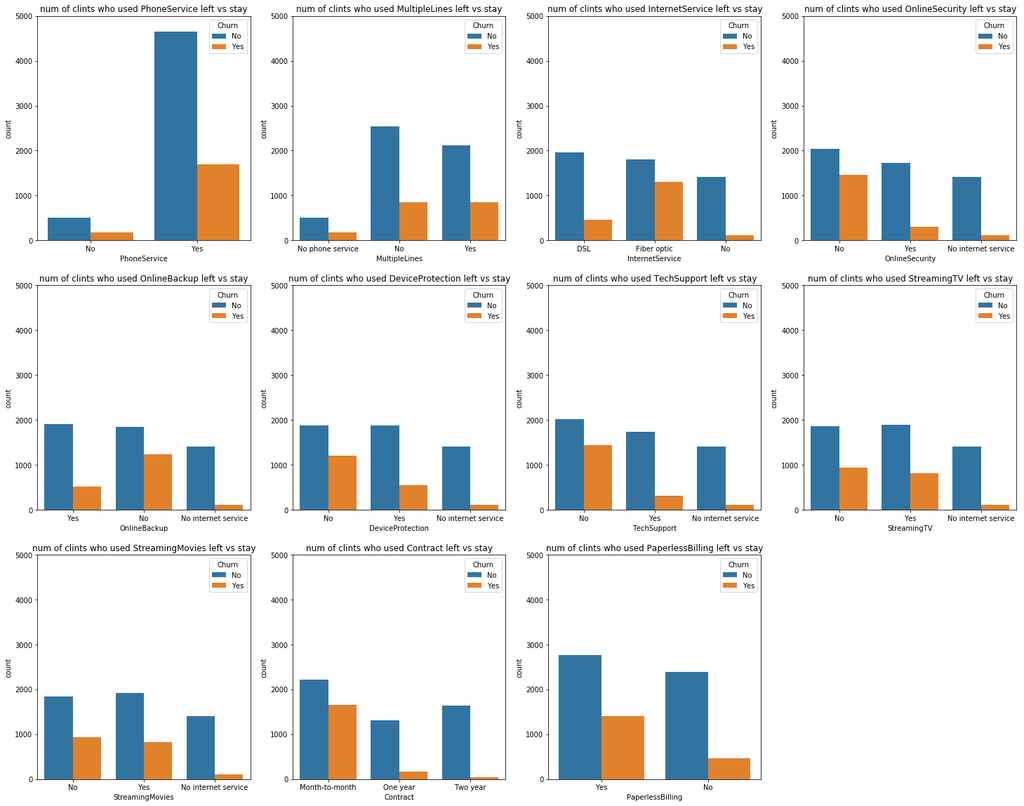

```python
plt.figure(figsize=(25,20))
for i,feature in enumerate(list(service.columns)):
    plt.subplot(3,4,i+1)
    sns.countplot(feature,hue = telco.Churn,data=telco)
    plt.ylim(0,5000)
    plt.title('num of clints who used {} left vs stay'.format(feature))
plt.show()
```

### The previous graph shows the relationship of leaving the company with services, and knowing the number of those who left the company and who remained in relation to using the services

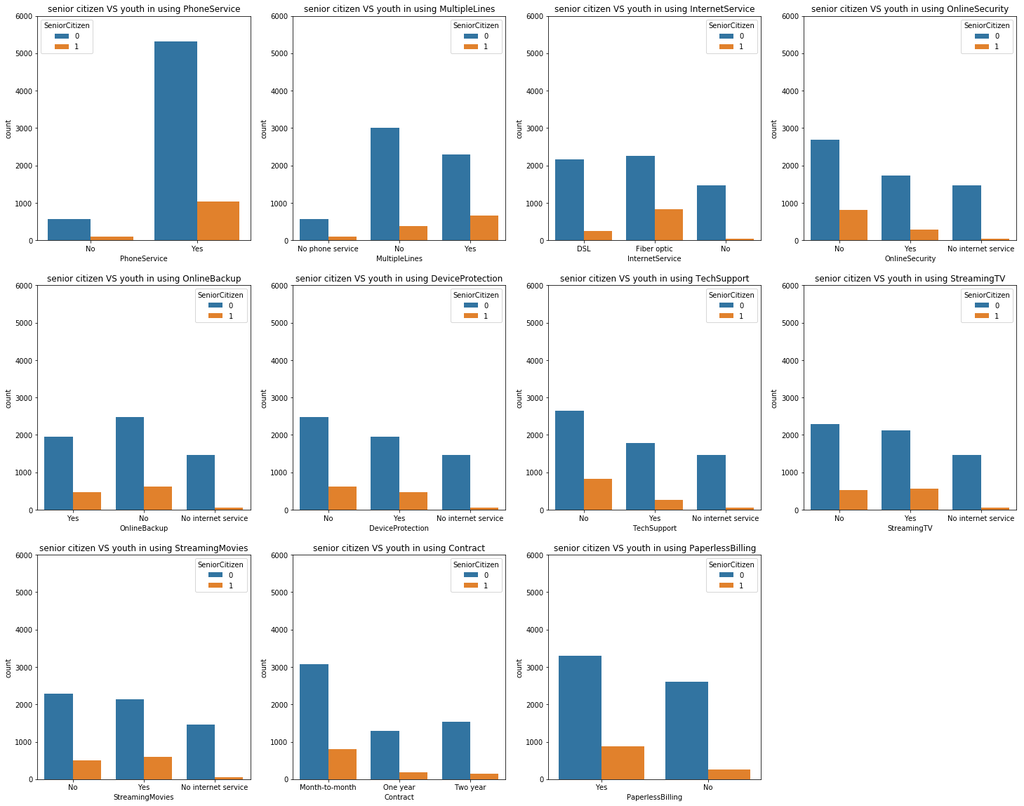

```python
plt.figure(figsize=(25,20))
for i,feature in enumerate(list(service.columns)):
    plt.subplot(3,4,i+1)
    sns.countplot(feature,hue = telco.SeniorCitizen,data=telco)
    plt.ylim(0,6000)
    plt.title('senior citizen VS youth in using {}'.format(feature))
plt.show()
```

### The previous plot aims to find out the number of elderly people who use different services and the number of young people who use the same services as well

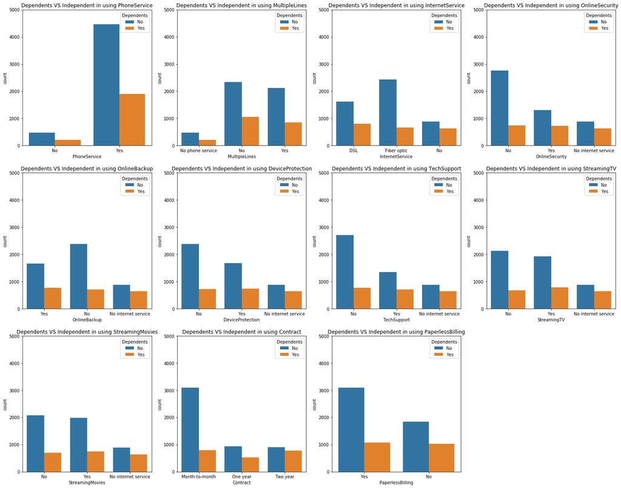

```python
plt.figure(figsize=(25,20))
for i,feature in enumerate(list(service.columns)):
    plt.subplot(3,4,i+1)
    sns.countplot(feature,hue = telco.Dependents,data=telco)
    plt.ylim(0,5000)
    plt.title('Dependents VS Independent in using {}'.format(feature))
plt.show()
```

### The previous plot aims to find out the number of dependent people who use different services and the number of independent people who use the same services as well

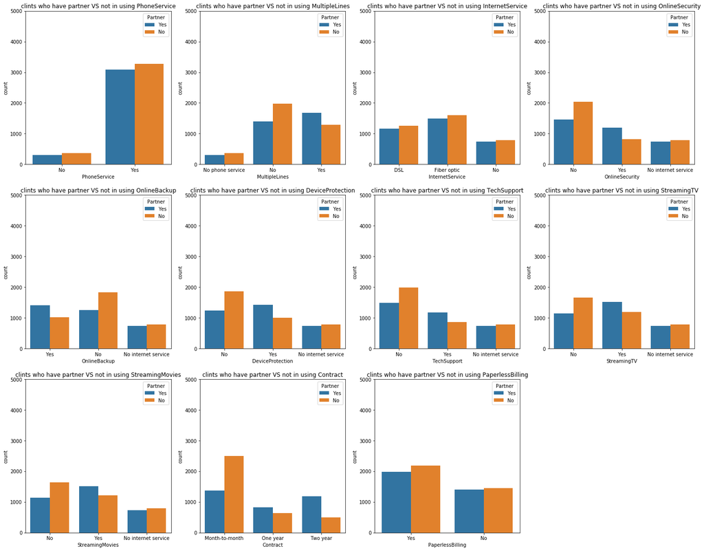

```python
plt.figure(figsize=(25,20))
for i,feature in enumerate(list(service.columns)):
    plt.subplot(3,4,i+1)
    sns.countplot(feature,hue = telco.Partner,data=telco)
    plt.ylim(0,5000)
    plt.title('clints who have partner VS not in using {}'.format(feature))
plt.show()
```

### The previous plot aims to find out the number of clients who has partner use different services and the number of clients who don't have partner use the same services as well

## Conclusions

there are senior citizens join the company and after few days they didn't find good servers suitable to them so they decided to leave, on the other hand, 33% of single clients also left the company after the found a lot of services more sutabile to clients with partners. a lot of clients using Fiber Optic and a lot of them left the company I think the quality is not good enough

## in the end there are some problems the company faces

- 41.7% of senior citizens left the company.
- 33% of customers who don't have a partner left the company.
- 31% of independent customers left the company
- 15.4% of dependent customers left the company
- 8.7% of customers left the company after the first month
- 19.3% of customers left the company after first 5 months
- A large number of customers using Fiber Optic have left the company
- Clients who do not use online security, many of them leave the company
- Many clients who do not use technical support have left the company
- Customers who pay month to month are the most who leave the company